# Emergency Department Data Analysis

```python
import pandas as pd
import seaborn as sns
```

```python
df = pd.read_csv('EmergencyDepartmentData.csv')
df.head()
```

|  | MRN | Presentation Visit Number | Triage Priority | Age (yrs) | Arrival Date | Dr Seen Date | Depart Actual Date | Depart Status Code | Departure Status Desc. | Depart. Dest. Code | Depart. Dest. Desc. | TimeDiff Arrival-Actual Depart (mins) | TimeDiff TreatDrNr-Act. Depart (mins) | Presenting Complaint Code | Presenting Complaint Desc. | Diag Code | Diagnosis Desc. |
| --- | --- | --- | --- | --- | --- | --- | --- | --- | --- | --- | --- | --- | --- | --- | --- | --- | --- |
| 0 | 67269 | 63190 | 3 | 15 | 01-01-09 | 01/01/09 | 01/01/09 | H | ED SERVICE EVENT COMPLETED - DISCHARGED | DISCH | * DISCHARGED | 733 | 619.0 | 4000.0 | DRUG / ALCOHOL / POISONING | F43.9 | EMOTIONAL CRISIS |
| 1 | 444991 | 63193 | 4 | 15 | 01-01-09 | 01/01/09 | 01/01/09 | W | DID NOT WAIT | DNW | * DID NOT WAIT | 420 | 274.0 | 9000.0 | INJURY | Z53.2 | DID NOT WAIT |
| 2 | 444992 | 63194 | 4 | 8 | 01-01-09 | 01/01/09 | 01/01/09 | H | ED SERVICE EVENT COMPLETED - DISCHARGED | DISCH | * DISCHARGED | 13 | 0.0 | 7000.0 | EYE | H10.9 | CONJUNCTIVITIS |
| 3 | 444999 | 63213 | 3 | 12 | 01-01-09 | 01/01/09 | 01/01/09 | H | ED SERVICE EVENT COMPLETED - DISCHARGED | DISCH | * DISCHARGED | 98 | 26.0 | 25000.0 | PAIN | H60.9 | OTITIS EXTERNA |
| 4 | 429921 | 63217 | 4 | 15 | 01-01-09 | 01/01/09 | 01/01/09 | H | ED SERVICE EVENT COMPLETED - DISCHARGED | DISCH | * DISCHARGED | 274 | 119.0 | 9000.0 | INJURY | S83.6 | KNEE SPRAIN / STRAIN |

## Data Exploration

Let's have a look at the average time at the hospital based on the type of complaint that the patient had. This is from the time they first arrived at the hospital to when they left.

```python
avg_time_hosp = df.groupby('Presenting Complaint Desc.')['TimeDiff Arrival-Actual Depart (mins)'].mean().reset_index()
```

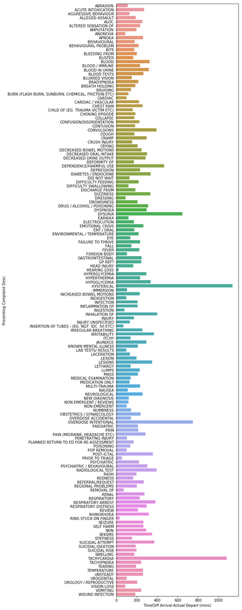

```python
import matplotlib.pyplot as plt
ax = plt.subplots(figsize=(6, 30))
ax = sns.barplot(x = avg_time_hosp['TimeDiff Arrival-Actual Depart (mins)'] , y = avg_time_hosp['Presenting Complaint Desc.'])
```

We can see from the above chart, patients complaining about dysuria, hysterical, intentional overdose and tachycardia spent the most time in the hospital. This could be helpful in predicting a patient's stay at the hospital based on their complaint. We can also see that hearing loss and ring stuck on a finger requires the shortest stays.

Next, let's take a look at their hospital stay time based on their diagnosis

```python
avg_time_diag = df.groupby('Diagnosis Desc.')['TimeDiff Arrival-Actual Depart (mins)'].mean().reset_index()
```

[figure not shown]

```python
ax = plt.subplots(figsize=(6, 120))
ax = sns.barplot(x = avg_time_diag['TimeDiff Arrival-Actual Depart (mins)'] , y = avg_time_diag['Diagnosis Desc.'])
```

We can see from the above chart that tibia-bimalleolar, cholecystitis-acute, haemoptysis, pneumothorax and tinnitus are some of the diagnoses that takes the longest hospital stays. Scalp Superficial Foreign Body and partial thickness burns area requires the shortest stays.

Wait times at the emergency is a pressing issue. Let's have a look at their initial priority assesment versus how much time they have spent waiting.

```python
df['wait_times'] = df['TimeDiff Arrival-Actual Depart (mins)'] - df['TimeDiff TreatDrNr-Act. Depart (mins)']
avg_wait_time = df.groupby('Triage Priority')['wait_times'].mean().reset_index()
```

```python
avg_wait_time
```

|  | Triage Priority | wait_times |
| --- | --- | --- |
| 0 | 1 | 0.585657 |
| 1 | 2 | 11.154380 |
| 2 | 3 | 57.348925 |
| 3 | 4 | 83.396025 |
| 4 | 5 | 65.075540 |

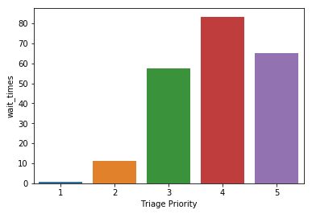

```python
#ax = plt.subplots(figsize=(6, 80))
ax = sns.barplot(x = avg_wait_time['Triage Priority'] , y = avg_wait_time['wait_times'])
```

Triage Priority 4 has significantly higher wait times than priority 5. This shows that the priority assessment system needs to be reevaluated.

Let's also look at the patients' departure destination.

```python
dep_dest_count = df['Depart. Dest. Desc.'].value_counts()
```

```python
dep_dest_count.divide(dep_dest_count.sum())*100
```

```
* DISCHARGED                              75.672453
2F - PAEDIATRICS                          10.431297
DID NOT WAIT                               7.864052
* DID NOT WAIT                             2.865377
TRANSFERRED TO ANOTHER HEALTH FACILITY     1.384656
* LEFT AGAINST MEDICAL ADVICE              0.639327
2A - MENTAL HEALTH                         0.414072
* CHOOSING TO ATTEND FMC (DNW)             0.152378
OTHER                                      0.096065
2I - ORTHOPEDICS                           0.092752
* DISCHARGE LIKELY                         0.089440
2H - SURGICAL WARD                         0.062939
* DID NOT WAIT PRIOR TO TRIAGE             0.053001
THEATRE SUITE                              0.036438
* ADMISSION LIKELY                         0.023188
DIED IN ED                                 0.019875
2G - MEDICAL WARD                          0.016563
INTENSIVE CARE UNIT                        0.016563
BIRTH SUITE                                0.016563
3A - MEDICAL WARD                          0.009938
3C - MEDICAL WARD                          0.009938
AOL - MENTAL HEALTH                        0.006625
2B - MENTAL HEALTH                         0.006625
3B - MEDICAL WARD                          0.006625
DEAD ON ARRIVAL                            0.003313
TRANSIT LOUNGE                             0.003313
POLICE OR CORRECTIONAL FACILITY            0.003313
2D - MATERNITY SUITE                       0.003313
Name: Depart. Dest. Desc., dtype: float64
```

We can see that 75% of the patients are discharged directly from the emergency and approximately 10 % of the patients did not wait at the emergency.

Age distribution of patients

```python
age_count = df[' Age  (yrs)'].value_counts()
```

```python
age_count.divide(age_count.sum())*100
```

```
0     15.446535
1     13.816748
2      9.970849
3      7.284351
15     6.128263
14     5.581688
4      5.502186
13     4.766795
5      4.587916
12     4.299722
11     3.955214
6      3.955214
10     3.872400
9      3.782960
8      3.551080
7      3.498079
Name:  Age  (yrs), dtype: float64
```

Let's look at the most common diagnoses at different ages

```python
diag_grps = df.pivot_table(index=["Diagnosis Desc."], columns=[" Age  (yrs)"], aggfunc=len)
diag_grps
```

| Age (yrs) Diagnosis Desc. | Arrival Date 0 | Arrival Date 1 | Arrival Date 2 | Arrival Date 3 | Arrival Date 4 | Arrival Date 5 | Arrival Date 6 | Arrival Date 7 | Arrival Date 8 | Arrival Date 9 | ... | wait_times 6 | wait_times 7 | wait_times 8 | wait_times 9 | wait_times 10 | wait_times 11 | wait_times 12 | wait_times 13 | wait_times 14 | wait_times 15 |
| --- | --- | --- | --- | --- | --- | --- | --- | --- | --- | --- | --- | --- | --- | --- | --- | --- | --- | --- | --- | --- | --- |
| # ACETABULUM | NaN | NaN | NaN | NaN | NaN | NaN | NaN | NaN | NaN | NaN | ... | NaN | NaN | NaN | NaN | NaN | NaN | NaN | NaN | 1.0 | NaN |
| # CALCANEUS | NaN | NaN | NaN | NaN | NaN | NaN | NaN | 1.0 | NaN | NaN | ... | NaN | 1.0 | NaN | NaN | 1.0 | NaN | NaN | NaN | NaN | 1.0 |
| # CARPAL BONES | NaN | NaN | NaN | NaN | NaN | NaN | NaN | NaN | NaN | NaN | ... | NaN | NaN | NaN | NaN | NaN | 1.0 | 1.0 | NaN | NaN | NaN |
| # CARPAL BONES - OTHER | NaN | 1.0 | NaN | NaN | NaN | NaN | NaN | NaN | NaN | 1.0 | ... | NaN | NaN | NaN | 1.0 | NaN | 2.0 | 2.0 | 1.0 | 6.0 | 5.0 |
| # CLAVICLE | 2.0 | 10.0 | 15.0 | 11.0 | 7.0 | 12.0 | 7.0 | 7.0 | 7.0 | 7.0 | ... | 7.0 | 7.0 | 7.0 | 7.0 | 8.0 | 10.0 | 18.0 | 25.0 | 27.0 | 26.0 |
| # FACIAL BONES | NaN | NaN | NaN | NaN | NaN | NaN | NaN | NaN | NaN | 1.0 | ... | NaN | NaN | NaN | 1.0 | 1.0 | NaN | NaN | NaN | NaN | 3.0 |
| # FEMUR - LOWER PART | 1.0 | NaN | 1.0 | NaN | 1.0 | 1.0 | NaN | NaN | NaN | NaN | ... | NaN | NaN | NaN | NaN | 1.0 | 1.0 | NaN | NaN | NaN | NaN |
| # FEMUR - SHAFT OR OTHER PART | 2.0 | NaN | 3.0 | NaN | NaN | 2.0 | NaN | 1.0 | NaN | NaN | ... | NaN | 1.0 | NaN | NaN | 1.0 | 1.0 | 1.0 | 1.0 | NaN | 1.0 |
| # FLAIL CHEST | NaN | NaN | 1.0 | NaN | NaN | NaN | NaN | NaN | NaN | NaN | ... | NaN | NaN | NaN | NaN | NaN | NaN | NaN | NaN | NaN | NaN |
| # FOOT - OTHER | NaN | NaN | 1.0 | 1.0 | 1.0 | 1.0 | NaN | 2.0 | 4.0 | 3.0 | ... | NaN | 2.0 | 4.0 | 3.0 | 2.0 | 3.0 | 3.0 | 3.0 | 3.0 | 8.0 |
| # HUMERUS - LOWER END | 2.0 | 17.0 | 28.0 | 20.0 | 36.0 | 32.0 | 26.0 | 21.0 | 17.0 | 16.0 | ... | 26.0 | 21.0 | 17.0 | 16.0 | 16.0 | 5.0 | 7.0 | 8.0 | 12.0 | 2.0 |
| # HUMERUS - SHAFT OR OTHER PART | 1.0 | NaN | NaN | NaN | 2.0 | 1.0 | NaN | NaN | NaN | NaN | ... | NaN | NaN | NaN | NaN | 2.0 | 1.0 | 3.0 | 1.0 | 2.0 | 1.0 |
| # HUMERUS - UPPER END | 1.0 | NaN | NaN | 3.0 | NaN | 1.0 | 3.0 | 3.0 | 6.0 | 8.0 | ... | 3.0 | 3.0 | 6.0 | 8.0 | 4.0 | 2.0 | 3.0 | 6.0 | 5.0 | 4.0 |
| # LUMBAR SPINE | NaN | NaN | NaN | NaN | NaN | NaN | NaN | NaN | NaN | NaN | ... | NaN | NaN | NaN | NaN | NaN | NaN | 1.0 | 1.0 | NaN | NaN |
| # MALAR OR MAXILLARY BONES | NaN | NaN | NaN | 1.0 | NaN | NaN | NaN | NaN | NaN | NaN | ... | NaN | NaN | NaN | NaN | NaN | NaN | 1.0 | NaN | 1.0 | NaN |
| # MANDIBLE | NaN | 1.0 | NaN | NaN | NaN | NaN | NaN | NaN | NaN | NaN | ... | NaN | NaN | NaN | NaN | 1.0 | 1.0 | NaN | 1.0 | 3.0 | 1.0 |
| # METACARPAL BONES | NaN | 1.0 | 2.0 | NaN | NaN | 1.0 | 2.0 | 1.0 | 3.0 | 7.0 | ... | 2.0 | 1.0 | 3.0 | 7.0 | 10.0 | 8.0 | 12.0 | 29.0 | 31.0 | 27.0 |
| # NASAL BONES | NaN | 4.0 | 1.0 | 3.0 | 1.0 | 3.0 | 2.0 | NaN | NaN | 3.0 | ... | 2.0 | NaN | NaN | 3.0 | 2.0 | 1.0 | 3.0 | 3.0 | 2.0 | 5.0 |
| # ORBITAL FLOOR BLOWOUT | NaN | NaN | NaN | NaN | NaN | NaN | NaN | NaN | 1.0 | NaN | ... | NaN | NaN | 1.0 | NaN | NaN | NaN | NaN | 1.0 | NaN | NaN |
| # PATELLA | NaN | NaN | NaN | NaN | NaN | NaN | NaN | NaN | NaN | NaN | ... | NaN | NaN | NaN | NaN | NaN | NaN | 3.0 | 3.0 | 3.0 | NaN |
| # PELVIC PUBIS | NaN | NaN | NaN | NaN | NaN | NaN | NaN | NaN | 1.0 | NaN | ... | NaN | NaN | 1.0 | NaN | NaN | NaN | NaN | NaN | NaN | NaN |
| # PELVIS | NaN | NaN | NaN | NaN | 1.0 | NaN | NaN | NaN | NaN | NaN | ... | NaN | NaN | NaN | NaN | 1.0 | NaN | NaN | NaN | NaN | NaN |
| # RADIUS - LOWER END | NaN | 4.0 | 13.0 | 9.0 | 11.0 | 27.0 | 32.0 | 38.0 | 48.0 | 53.0 | ... | 32.0 | 38.0 | 48.0 | 53.0 | 60.0 | 59.0 | 57.0 | 42.0 | 43.0 | 23.0 |
| # RADIUS - OTHER PART | NaN | 1.0 | 3.0 | 8.0 | 6.0 | 5.0 | 6.0 | 4.0 | 5.0 | 10.0 | ... | 6.0 | 4.0 | 5.0 | 10.0 | 9.0 | 10.0 | 8.0 | 8.0 | 6.0 | 6.0 |
| # RADIUS AND ULNA | 1.0 | 17.0 | 19.0 | 16.0 | 17.0 | 29.0 | 39.0 | 26.0 | 26.0 | 21.0 | ... | 39.0 | 26.0 | 26.0 | 21.0 | 26.0 | 28.0 | 18.0 | 28.0 | 15.0 | 7.0 |
| # RIBS | NaN | NaN | NaN | NaN | NaN | NaN | NaN | NaN | NaN | NaN | ... | NaN | NaN | NaN | NaN | 1.0 | NaN | NaN | 1.0 | 3.0 | 2.0 |
| # SCAPHOID | NaN | NaN | NaN | NaN | NaN | NaN | NaN | NaN | 2.0 | 2.0 | ... | NaN | NaN | 2.0 | 2.0 | 7.0 | 5.0 | 8.0 | 21.0 | 9.0 | 7.0 |
| # SCAPULA | NaN | NaN | NaN | NaN | NaN | NaN | NaN | 1.0 | NaN | NaN | ... | NaN | 1.0 | NaN | NaN | NaN | 1.0 | NaN | 1.0 | 3.0 | 1.0 |
| # TARSAL OR METATARSAL BONES | NaN | 3.0 | 2.0 | 1.0 | 3.0 | 5.0 | 3.0 | 1.0 | 2.0 | 6.0 | ... | 3.0 | 1.0 | 2.0 | 6.0 | 11.0 | 5.0 | 11.0 | 11.0 | 10.0 | 11.0 |
| # THUMB | NaN | 1.0 | NaN | 1.0 | 2.0 | NaN | NaN | 2.0 | 2.0 | 2.0 | ... | NaN | 2.0 | 2.0 | 2.0 | 2.0 | 4.0 | 11.0 | 13.0 | 6.0 | 10.0 |
| ... | ... | ... | ... | ... | ... | ... | ... | ... | ... | ... | ... | ... | ... | ... | ... | ... | ... | ... | ... | ... | ... |
| TRAUMA TO SPLEEN | NaN | NaN | NaN | NaN | NaN | NaN | NaN | NaN | NaN | NaN | ... | NaN | NaN | NaN | NaN | NaN | 2.0 | 1.0 | 2.0 | 1.0 | NaN |
| TRAUMATIC AMPUTATION OF FOOT &/ TOE(S) | NaN | NaN | 1.0 | NaN | NaN | NaN | NaN | NaN | NaN | NaN | ... | NaN | NaN | NaN | NaN | NaN | NaN | NaN | NaN | NaN | NaN |
| TRAUMATIC AMPUTATION OF HAND &/ FINGER(S) | 1.0 | NaN | NaN | 3.0 | NaN | 1.0 | NaN | NaN | NaN | NaN | ... | NaN | NaN | NaN | NaN | NaN | NaN | NaN | NaN | NaN | NaN |
| TRUNK ABRASION | NaN | NaN | NaN | 3.0 | NaN | 1.0 | 1.0 | 1.0 | 1.0 | 2.0 | ... | 1.0 | 1.0 | 1.0 | 2.0 | 3.0 | 3.0 | NaN | 1.0 | NaN | 1.0 |
| TRUNK SUPERFICIAL FOREIGN BODY | NaN | NaN | NaN | NaN | NaN | NaN | NaN | NaN | NaN | NaN | ... | NaN | NaN | NaN | NaN | NaN | NaN | 1.0 | 1.0 | NaN | NaN |
| UMBILICAL DISCHARGE | 17.0 | NaN | NaN | NaN | NaN | NaN | NaN | NaN | NaN | NaN | ... | NaN | NaN | NaN | NaN | NaN | NaN | NaN | NaN | NaN | NaN |
| UMBILICAL HERNIA | 7.0 | NaN | NaN | 1.0 | NaN | NaN | 1.0 | NaN | NaN | NaN | ... | 1.0 | NaN | NaN | NaN | NaN | NaN | NaN | NaN | NaN | NaN |
| UNCONSCIOUS ? CAUSE | 1.0 | NaN | NaN | NaN | 1.0 | NaN | NaN | NaN | NaN | 1.0 | ... | NaN | NaN | NaN | 1.0 | NaN | NaN | NaN | NaN | NaN | 1.0 |
| UNDESCENDED TESTIS/CRYPTORCHISM | NaN | NaN | 1.0 | NaN | NaN | NaN | NaN | 1.0 | NaN | NaN | ... | NaN | 1.0 | NaN | NaN | NaN | NaN | NaN | NaN | NaN | NaN |
| UPPER ARM SPRAIN / STRAIN | 1.0 | 4.0 | 3.0 | 1.0 | NaN | 2.0 | 3.0 | 3.0 | 1.0 | 3.0 | ... | 3.0 | 3.0 | 1.0 | 3.0 | NaN | 1.0 | 2.0 | 1.0 | 1.0 | 3.0 |
| UPPER RESPIRATORY TRACT INFECTION | 524.0 | 451.0 | 231.0 | 143.0 | 83.0 | 53.0 | 40.0 | 35.0 | 21.0 | 20.0 | ... | 40.0 | 35.0 | 21.0 | 20.0 | 18.0 | 19.0 | 15.0 | 14.0 | 11.0 | 21.0 |
| URINARY CALCULUS | NaN | NaN | NaN | NaN | NaN | NaN | NaN | NaN | NaN | NaN | ... | NaN | NaN | NaN | NaN | NaN | NaN | NaN | NaN | 1.0 | NaN |
| URINARY RETENTION | NaN | NaN | 3.0 | NaN | NaN | NaN | NaN | 1.0 | NaN | 1.0 | ... | NaN | 1.0 | NaN | 1.0 | NaN | NaN | NaN | NaN | NaN | 1.0 |
| URINARY TRACT INFECTION | 56.0 | 28.0 | 23.0 | 20.0 | 25.0 | 28.0 | 16.0 | 20.0 | 20.0 | 12.0 | ... | 16.0 | 20.0 | 20.0 | 12.0 | 11.0 | 8.0 | 2.0 | 5.0 | 12.0 | 28.0 |
| VAGINAL FOREIGN BODY | NaN | NaN | NaN | NaN | NaN | NaN | NaN | NaN | NaN | NaN | ... | NaN | NaN | NaN | NaN | NaN | NaN | NaN | NaN | NaN | 1.0 |
| VAGINAL OR VULVAL INFECTION | NaN | 1.0 | 2.0 | 1.0 | 1.0 | NaN | NaN | NaN | NaN | NaN | ... | NaN | NaN | NaN | NaN | NaN | NaN | NaN | NaN | NaN | 2.0 |
| VALVULAR HEART DISEASE | NaN | NaN | NaN | NaN | NaN | NaN | NaN | NaN | NaN | NaN | ... | NaN | NaN | NaN | NaN | 1.0 | NaN | NaN | NaN | NaN | NaN |
| VENTRICULAR TACHYCARDIA | NaN | NaN | NaN | NaN | NaN | NaN | NaN | NaN | 1.0 | NaN | ... | NaN | NaN | 1.0 | NaN | NaN | NaN | NaN | NaN | NaN | 1.0 |
| VERTIGO | NaN | NaN | NaN | NaN | NaN | NaN | NaN | NaN | NaN | NaN | ... | NaN | NaN | NaN | NaN | NaN | NaN | NaN | NaN | NaN | 1.0 |
| VIRAL CONJUNCTIVITIS | 3.0 | 2.0 | 1.0 | 1.0 | NaN | 1.0 | NaN | NaN | 3.0 | 1.0 | ... | NaN | NaN | 3.0 | 1.0 | NaN | NaN | 1.0 | 1.0 | 1.0 | NaN |
| VIRAL EXANTHEMA | 15.0 | 18.0 | 1.0 | 3.0 | 4.0 | 1.0 | 1.0 | NaN | NaN | NaN | ... | 1.0 | NaN | NaN | NaN | NaN | 1.0 | NaN | NaN | 2.0 | NaN |
| VIRAL GASTROENTERITIS | 233.0 | 176.0 | 115.0 | 79.0 | 38.0 | 40.0 | 27.0 | 24.0 | 20.0 | 24.0 | ... | 27.0 | 24.0 | 20.0 | 24.0 | 19.0 | 20.0 | 19.0 | 13.0 | 7.0 | 14.0 |
| VIRAL INFECTION | 266.0 | 229.0 | 143.0 | 75.0 | 53.0 | 39.0 | 44.0 | 23.0 | 30.0 | 20.0 | ... | 44.0 | 23.0 | 30.0 | 20.0 | 24.0 | 22.0 | 11.0 | 10.0 | 21.0 | 17.0 |
| VIRAL WARTS/PAPILLOMA | NaN | NaN | NaN | NaN | NaN | NaN | NaN | NaN | NaN | NaN | ... | NaN | NaN | NaN | NaN | NaN | NaN | NaN | NaN | 1.0 | NaN |
| WARFARIN POISONING | NaN | NaN | 1.0 | NaN | NaN | NaN | NaN | NaN | NaN | NaN | ... | NaN | NaN | NaN | NaN | NaN | NaN | 1.0 | NaN | 1.0 | NaN |
| WOUND INFECTION | 4.0 | 3.0 | 1.0 | 1.0 | 1.0 | NaN | NaN | NaN | 6.0 | NaN | ... | NaN | NaN | 6.0 | NaN | 2.0 | NaN | 3.0 | 3.0 | 2.0 | 1.0 |
| WRIST CRUSH INJURY | NaN | NaN | NaN | NaN | NaN | NaN | NaN | NaN | NaN | NaN | ... | NaN | NaN | NaN | NaN | 1.0 | NaN | NaN | 1.0 | NaN | NaN |
| WRIST HAND OR FINGER ABRASION | 1.0 | 2.0 | 1.0 | 2.0 | NaN | NaN | 1.0 | 3.0 | 1.0 | 2.0 | ... | 1.0 | 3.0 | 1.0 | 2.0 | NaN | 1.0 | 3.0 | NaN | 1.0 | 1.0 |
| WRIST SPRAIN / STRAIN | NaN | 11.0 | 14.0 | 5.0 | 4.0 | 4.0 | 4.0 | 8.0 | 13.0 | 18.0 | ... | 4.0 | 8.0 | 13.0 | 18.0 | 34.0 | 39.0 | 34.0 | 18.0 | 29.0 | 20.0 |
| WRY NECK | NaN | NaN | NaN | NaN | 2.0 | NaN | 1.0 | NaN | NaN | NaN | ... | 1.0 | NaN | NaN | NaN | 1.0 | 1.0 | NaN | NaN | 1.0 | NaN |

660 rows × 256 columns

This matrix shows the number of patients of a specific age who are diagnosed with a particular disease.

```python
diag_age = df.groupby('Diagnosis Desc.')[' Age  (yrs)'].count().reset_index()
diag_age
```

|  | Diagnosis Desc. | Age (yrs) |
| --- | --- | --- |
| 0 | # ACETABULUM | 1 |
| 1 | # CALCANEUS | 3 |
| 2 | # CARPAL BONES | 2 |
| 3 | # CARPAL BONES - OTHER | 18 |
| 4 | # CLAVICLE | 199 |
| 5 | # FACIAL BONES | 5 |
| 6 | # FEMUR - LOWER PART | 6 |
| 7 | # FEMUR - SHAFT OR OTHER PART | 13 |
| 8 | # FLAIL CHEST | 1 |
| 9 | # FOOT - OTHER | 35 |
| 10 | # HUMERUS - LOWER END | 265 |
| 11 | # HUMERUS - SHAFT OR OTHER PART | 14 |
| 12 | # HUMERUS - UPPER END | 49 |
| 13 | # LUMBAR SPINE | 2 |
| 14 | # MALAR OR MAXILLARY BONES | 3 |
| 15 | # MANDIBLE | 8 |
| 16 | # METACARPAL BONES | 134 |
| 17 | # NASAL BONES | 33 |
| 18 | # ORBITAL FLOOR BLOWOUT | 2 |
| 19 | # PATELLA | 9 |
| 20 | # PELVIC PUBIS | 1 |
| 21 | # PELVIS | 2 |
| 22 | # RADIUS - LOWER END | 519 |
| 23 | # RADIUS - OTHER PART | 95 |
| 24 | # RADIUS AND ULNA | 333 |
| 25 | # RIBS | 7 |
| 26 | # SCAPHOID | 61 |
| 27 | # SCAPULA | 7 |
| 28 | # TARSAL OR METATARSAL BONES | 85 |
| 29 | # THUMB | 56 |
| ... | ... | ... |
| 630 | TRAUMA TO SPLEEN | 6 |
| 631 | TRAUMATIC AMPUTATION OF FOOT &/ TOE(S) | 1 |
| 632 | TRAUMATIC AMPUTATION OF HAND &/ FINGER(S) | 5 |
| 633 | TRUNK ABRASION | 17 |
| 634 | TRUNK SUPERFICIAL FOREIGN BODY | 2 |
| 635 | UMBILICAL DISCHARGE | 17 |
| 636 | UMBILICAL HERNIA | 9 |
| 637 | UNCONSCIOUS ? CAUSE | 4 |
| 638 | UNDESCENDED TESTIS/CRYPTORCHISM | 2 |
| 639 | UPPER ARM SPRAIN / STRAIN | 29 |
| 640 | UPPER RESPIRATORY TRACT INFECTION | 1699 |
| 641 | URINARY CALCULUS | 1 |
| 642 | URINARY RETENTION | 6 |
| 643 | URINARY TRACT INFECTION | 314 |
| 644 | VAGINAL FOREIGN BODY | 1 |
| 645 | VAGINAL OR VULVAL INFECTION | 7 |
| 646 | VALVULAR HEART DISEASE | 1 |
| 647 | VENTRICULAR TACHYCARDIA | 2 |
| 648 | VERTIGO | 1 |
| 649 | VIRAL CONJUNCTIVITIS | 15 |
| 650 | VIRAL EXANTHEMA | 46 |
| 651 | VIRAL GASTROENTERITIS | 868 |
| 652 | VIRAL INFECTION | 1027 |
| 653 | VIRAL WARTS/PAPILLOMA | 1 |
| 654 | WARFARIN POISONING | 3 |
| 655 | WOUND INFECTION | 27 |
| 656 | WRIST CRUSH INJURY | 2 |
| 657 | WRIST HAND OR FINGER ABRASION | 19 |
| 658 | WRIST SPRAIN / STRAIN | 255 |
| 659 | WRY NECK | 6 |

660 rows × 2 columns

We can see from above that most common diagnoses are clavicle, humerus-lower end, metacarpal bones, radius, upper respiratory tract infection, urinary tract infection, viral gastroenteritis, viral infection and wrist sprain.

## Predictive Models

Predict wait times.

We will use linear regression for the prediction. All unnecessary features have been removed like the identification numbers, and diagnosis data as it would not have direct impact on the wait times because it happens after the wait.

Remove unnecessary features and assign the X which would be the training features and Y which would the output label.

```python
select_features = ['Triage Priority', ' Age  (yrs)', 'Presenting Complaint Code']
X = df[select_features]
Y = df['wait_times']
```

Checking to see if any values in X is empty

```python
X.isnull().any()
```

```
Triage Priority              False
 Age  (yrs)                  False
Presenting Complaint Code     True
dtype: bool
```

Replace them with 0

```python
X.fillna(0, inplace=True)
```

Checking to see if any values in Y is empty

```python
Y.isnull().any()
```

```
True
```

Replace them with 0

```python
Y.fillna(0, inplace=True)
```

Split data for training and testing. 80% will be used for training and 20% for testing.

```python
from sklearn.cross_validation import train_test_split
X_train, X_test, y_train, y_test = train_test_split(
    X, Y, test_size=0.20)
```

Import linear regression and train the model.

```python
from sklearn.linear_model import LinearRegression
lr = LinearRegression()
lr.fit(X_train, y_train)
```

```
LinearRegression(copy_X=True, fit_intercept=True, n_jobs=1, normalize=False)
```

Predict using the model

```python
y_pred = lr.predict(X_test)
```

Calculate the root mean squared error of the testing data to evaluate the model.

```python
import numpy as np
from sklearn import metrics

print(np.sqrt(metrics.mean_squared_error(y_test, y_pred)))
```

```
68.49117669040544
```

Also check the root mean squared error of training data

```python
y_pred_train = lr.predict(X_train)
```

```python
print(np.sqrt(metrics.mean_squared_error(y_train, y_pred_train)))
```

```
68.10365701230923
```

Both the training and testing RMSE are close to each other. This shows that there is minimal overfitting.

Print the coefficients and intercept of the model

```python
lr.coef_
```

```
array([ 2.38368591e+01,  2.43421029e-01, -4.96794396e-05])
```

```python
lr.intercept_
```

```
-17.147781818513067
```

Predict Diagnosis using classification techniques.k-nn classifier is used.

Select appropriate features

```python
select_features = ['Triage Priority', ' Age  (yrs)', 'Presenting Complaint Code']
X = df[select_features]
Y = df['Diagnosis Desc.']
```

Fill empty cells

```python
X.fillna(0, inplace=True)
Y.fillna(0, inplace=True)
```

Split data into training and testing

```python
X_train, X_test, y_train, y_test = train_test_split(
    X, Y, test_size=0.20)
```

Use knn classifier with 500 neighbors and the points are weighted by the inverse of their distance

```python
from sklearn.neighbors import KNeighborsClassifier
nb = KNeighborsClassifier(n_neighbors=500,weights='distance')
nb.fit(X_train, y_train)
```

```
KNeighborsClassifier(algorithm='auto', leaf_size=30, metric='minkowski',
           metric_params=None, n_jobs=1, n_neighbors=500, p=2,
           weights='distance')
```

```python
y_pred = nb.predict(X_test)
print (y_pred)
```

```
['VIRAL GASTROENTERITIS' 'DID NOT WAIT' 'DID NOT WAIT' ... 'DID NOT WAIT'
 'UPPER RESPIRATORY TRACT INFECTION' 'DID NOT WAIT']
```

```python
from sklearn.metrics import classification_report
print ("Classification report: \n", (classification_report(y_test, y_pred)))
```

```
Classification report:
                                                                  precision    recall  f1-score   support

                                                   # ACETABULUM       0.00      0.00      0.00         1
                                                 # CARPAL BONES       0.00      0.00      0.00         1
                                         # CARPAL BONES - OTHER       0.00      0.00      0.00         1
                                                     # CLAVICLE       0.02      0.03      0.02        34
                                                 # FACIAL BONES       0.00      0.00      0.00         1
                                           # FEMUR - LOWER PART       0.00      0.00      0.00         0
                                  # FEMUR - SHAFT OR OTHER PART       0.00      0.00      0.00         2
                                                 # FOOT - OTHER       0.00      0.00      0.00         8
                                          # HUMERUS - LOWER END       0.00      0.00      0.00        49
                                # HUMERUS - SHAFT OR OTHER PART       0.00      0.00      0.00         1
                                          # HUMERUS - UPPER END       0.00      0.00      0.00         8
                                                 # LUMBAR SPINE       0.00      0.00      0.00         2
                                                     # MANDIBLE       0.00      0.00      0.00         2
                                             # METACARPAL BONES       0.00      0.00      0.00        23
                                                  # NASAL BONES       0.00      0.00      0.00         7
                                        # ORBITAL FLOOR BLOWOUT       0.00      0.00      0.00         0
                                                      # PATELLA       0.00      0.00      0.00         2
                                                 # PELVIC PUBIS       0.00      0.00      0.00         1
                                           # RADIUS - LOWER END       0.07      0.25      0.11       106
                                          # RADIUS - OTHER PART       0.00      0.00      0.00        15
                                              # RADIUS AND ULNA       0.16      0.12      0.14        57
                                                         # RIBS       0.00      0.00      0.00         1
                                                     # SCAPHOID       0.00      0.00      0.00        14
                                                      # SCAPULA       0.00      0.00      0.00         1
                                   # TARSAL OR METATARSAL BONES       0.00      0.00      0.00        17
                                                        # THUMB       0.00      0.00      0.00         9
                                    # TIBIA - LATERAL MALLEOLUS       0.00      0.00      0.00         3
                                     # TIBIA - MEDIAL MALLEOLUS       0.00      0.00      0.00         4
                                           # TIBIA - OTHER PART       0.00      0.00      0.00         7
                                                # TIBIA - SHAFT       0.00      0.00      0.00        11
                                         # TIBIA - TRIMALLEOLAR       0.00      0.00      0.00         1
                                            # TIBIA - UPPER END       0.00      0.00      0.00         8
                                                # TOOTH / TEETH       0.00      0.00      0.00         7
                                                         # ULNA       0.00      0.00      0.00        19
                            ABDO PAIN - LOCALISED TO LOWER ABDO       0.09      0.30      0.14        63
                            ABDO PAIN - LOCALISED TO UPPER ABDO       0.50      0.04      0.07        28
                                         ABDOMINAL PAIN - ACUTE       0.00      0.00      0.00        11
```

[output cut: 409 more lines]

```
                              UPPER RESPIRATORY TRACT INFECTION       0.15      0.40      0.21       354
                                              URINARY RETENTION       0.00      0.00      0.00         1
                                        URINARY TRACT INFECTION       0.22      0.03      0.06        61
                                    VAGINAL OR VULVAL INFECTION       0.00      0.00      0.00         1
                                        VENTRICULAR TACHYCARDIA       0.00      0.00      0.00         1
                                                        VERTIGO       0.00      0.00      0.00         1
                                           VIRAL CONJUNCTIVITIS       0.00      0.00      0.00         2
                                                VIRAL EXANTHEMA       0.00      0.00      0.00         8
                                          VIRAL GASTROENTERITIS       0.32      0.34      0.33       182
                                                VIRAL INFECTION       0.18      0.01      0.03       206
                                                WOUND INFECTION       0.00      0.00      0.00         7
                                  WRIST HAND OR FINGER ABRASION       0.00      0.00      0.00         1
                                          WRIST SPRAIN / STRAIN       0.50      0.02      0.03        56

                                                    avg / total       0.13      0.17      0.12      6038
```

This classification report shows the precision, recall, F1 score and support (count) of each of the classes. Since, it has a large number of classes the scores are not very high. Other classification models need to be tried to see if the scores can be improved.

Predict triage priority number based on age and complaint

```python
select_features = [' Age  (yrs)', 'Presenting Complaint Code']
X = df[select_features]
Y = df['Triage Priority']
```

```python
X.fillna(0, inplace=True)
Y.fillna(0, inplace=True)
```

```python
X_train, X_test, y_train, y_test = train_test_split(
    X, Y, test_size=0.20)
```

```python
from sklearn.ensemble import RandomForestClassifier
clf = RandomForestClassifier(random_state=0)
clf.fit(X_train,y_train)
```

```
RandomForestClassifier(bootstrap=True, class_weight=None, criterion='gini',
            max_depth=None, max_features='auto', max_leaf_nodes=None,
            min_impurity_decrease=0.0, min_impurity_split=None,
            min_samples_leaf=1, min_samples_split=2,
            min_weight_fraction_leaf=0.0, n_estimators=10, n_jobs=1,
            oob_score=False, random_state=0, verbose=0, warm_start=False)
```

```python
y_pred = clf.predict(X_test)
```

```python
from sklearn.metrics import classification_report
print ("Classification report: \n", (classification_report(y_test, y_pred)))
```

```
Classification report:
              precision    recall  f1-score   support

          1       0.67      0.08      0.14        50
          2       0.32      0.03      0.05       451
          3       0.68      0.82      0.75      3561
          4       0.52      0.45      0.48      1746
          5       0.63      0.49      0.55       230

avg / total       0.61      0.64      0.61      6038
```

The F1 score is 0.61 for predicting triage priority based on the age and complaint using Random Forest.